# Influence on Prosper Loan BorrowerAPR By Other Features

## by Benjamin Onyenekwe

## Investigation Overview

The goal of this presentation, is to show the effect of borrower obtainable features such as: BorrowerState, IsBorrowerHomeowner, IncomeRange, and others, on BorrowerAPR of prosper loans. The presentation, show the interaction of some features with BorrowerAPR, explored in three different stages; Univeariate, Bivariate and Multivariate to come up with findings which are also presented here, in regards to how they influence BorrowerAPR.

The distributions of some features in the prosper loan dataset revealed interesting insights that was what looking into, some requiring feature engineering. Exploring the interaction of each considered feature with BorrowerAPR uncovered intersting insights regarding BorrowerAPR. Although some feature showed no insight in the direction of exploration.

The presentation shows the distribution of features such as BorrowerAPR, BorrowerState, BorrowerRegion, IsBorrowerHomeowner, IncomeRange, and others. It also conveys reson for feature engineering done in the exploration and the difference made in visual analysis. Also presented is the interaction between BorrowerAPR, and features of interests - some already mentioned. These interactions inlude bivariate interactions and multivariate interactins in regards to how BorrowerAPR is influenced by these features.

## Dataset Overview

Prosper loan dataset contains 113,937 records (rows) of loans taken and 81 features (columns). Among the columns, is the LoanKey column, which uniquely identifies every loan in the dataset. Other columns include BorrowerAPR, LenderYield, BorrowerState and many more.

The distribution of the BorrowerAPR feature was bimodal but quite close to a normal distribution as can be seen from the frequency plot and density plot.

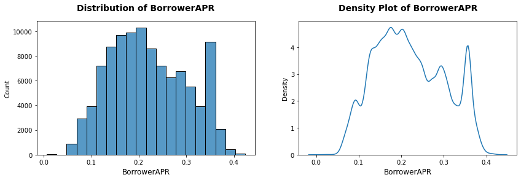

The distribution of the `BorrowerState` - shown in the next plot, lacked some meaningful visualization as can be seen in the frequency plot. This led to the engineering of a new feature **`BorrowerRegion`** that was based on the US Census Bureau-designated regions.

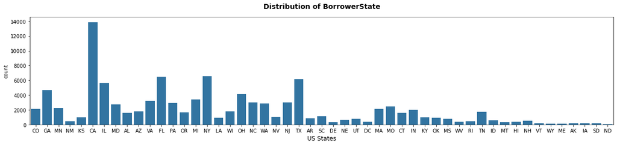

`BorrowerRegion` is made up of four region classes, namely: Northest, Midwest, South and West, which as can be seen from the next plot, follow the order of the US Censors of 2020 (also same since 1990) in regards to population size. That is, from largest to smallest in population size, South, West, Midwest, and Northeast. The distribution being inline with population size indicated a fair spread of borrowers across the United states.

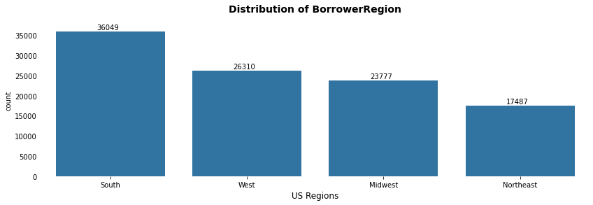

The records were also quite evenly distributed among borrowers who owned homes and those who do not own homes (i.e., `IsBorrowerHomeowner` feature)

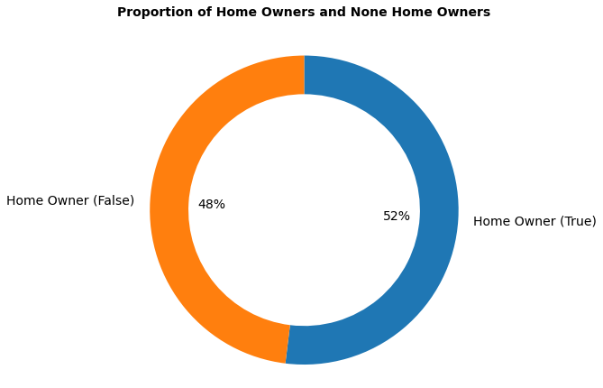

The distribution of the `IncomeRange` feature made it known that majority of the borrowers come from the two middle income class, \$25,499 - 49,999 and \$50,000-74,999.

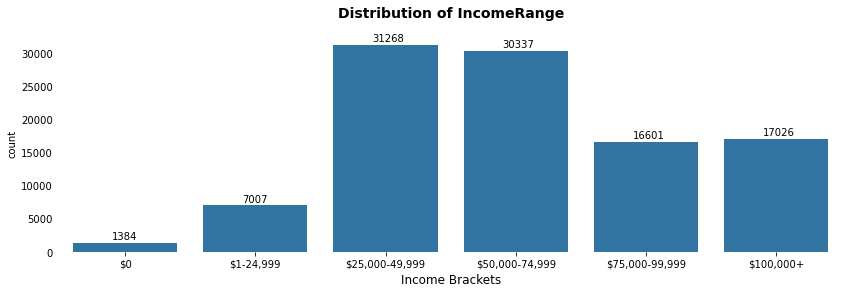

About 80% of the borrowers had not taken a prosper loan before, as can be seen from the distribution of the `TotalProsperLoans`.

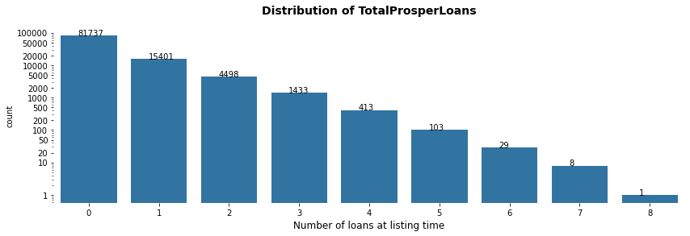

The distribution of the `CreditScoreRangeLower` and `CreditScoreRangeUpper` features were similar as can be seen in their frequency plots but, just like the BorrowerState feature, both lacked intuition. This lead to engineering of a new feature **`FicoClass`** which conveyed better insight.

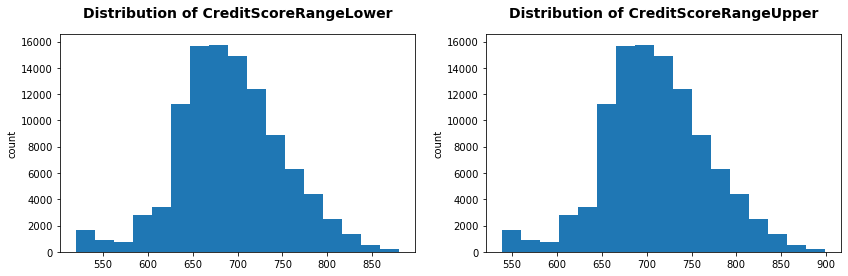

Credit scores are more meaningfull when read with a model such as the Fair Isaac Corporation (FICO) model. More information about FICO can be found online [here](https://www.experian.com/blogs/ask-experian/infographic-what-are-the-different-scoring-ranges/)

From the plot of the distribution of credit scores put into FICO classes (FicoClass) - a better representation of the frequency plot of CreditScoreRangeLower and CreditScoreRangeUpper combined, it can be seen that most borrowers are in the FICO class 'Good'.

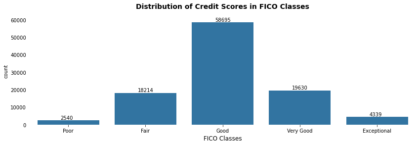

Although majority of the borrowers had credit score in FicoClass Good, the pattern of the median BorrowerAPR was a decreasing one as the credit score got better. Implying a lower BorrowerAPR for those with fine credit score, as can be seen in the next plot.

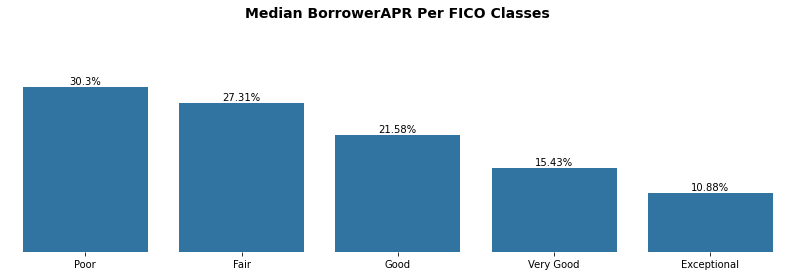

Observing the spread of each FicoClass with a violinplot in regards to the BorrowerAPR revealed; an increase in count of those who got lower BorrowerAPR moving up the FICO class. Moving down the FICO classes shows an increase in count of those who got higher borrowerAPR.

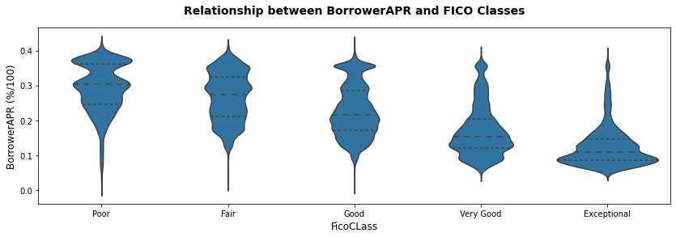

In order to gain more insight into the pattern observed from FICO classes, the middle class 'Good' was explored more to understand observed distribution peaks of this class at BorrowerAPR higher than 0.2 percent.

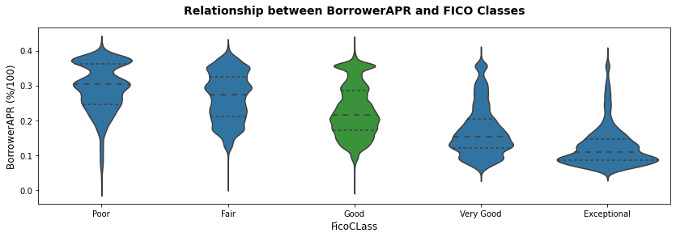

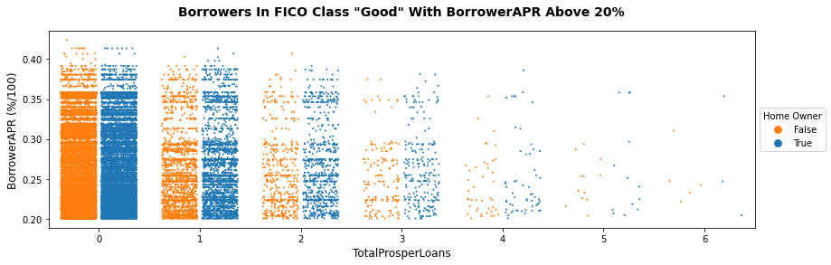

Also as observed from the plot below, these borrowers had income but their income range did not seem to matter much.

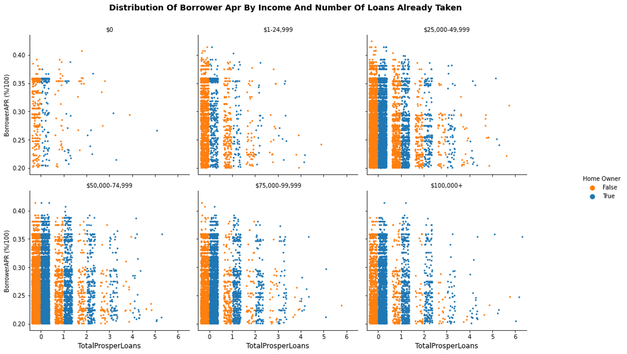

BorrowerAPR varies across credit scores, that is, the better the credit score (i.e., better FICO Class), the lower the BorrowerAPR. For First time Borrowers with credit score in the FICO class 'Good', it is possible to have a BorrowerAPR above 20%. This BorrowerAPR is not dependant on whether they own a house or not, or if they have an income.